# 784 Lab 1: R Refresher: Answer Key

```r
?sapply()
?lapply()


#using apply
medians2 <- apply(swiss, 2, median)
print(medians2)
```

```
##        Fertility      Agriculture      Examination        Education
##            70.40            54.10            16.00             8.00
##         Catholic Infant.Mortality       Protestant
##            15.14            20.00            84.86
```

```r
typeof(medians2)
```

```
## [1] "double"
```

```r
#it created a named vector

#using lapply
medians3 <- lapply(swiss, median)
print(medians3)
```

```
## $Fertility
## [1] 70.4
##
## $Agriculture
## [1] 54.1
##
## $Examination
## [1] 16
##
## $Education
## [1] 8
##
## $Catholic
## [1] 15.14
##
## $Infant.Mortality
## [1] 20
##
## $Protestant
## [1] 84.86
```

```r
typeof(medians3)
```

```
## [1] "list"
```

```r
#outputs a named list

#using sapply
medians4 <- sapply(swiss, median)
print(medians4)
```

```
##        Fertility      Agriculture      Examination        Education
##            70.40            54.10            16.00             8.00
##         Catholic Infant.Mortality       Protestant
##            15.14            20.00            84.86
```

```r
typeof(medians4)
```

```
## [1] "double"
```

```r
#outputs a named vector
```

9. Now we will explore `ggplot2`, which is a great package for plotting data and results. You will probably grow to have a love/hate relationship with `ggplot2`. For help with this package, reference this cheat sheet: https://res.cloudinary.com/dyd911kmh/image/upload/v1666806657/Marketing/Blog/ggplot2_cheat_sheet.pdf. Here is another useful link to a variety of graphs created using ggplot2: http://r-graph-gallery.com/
- Reminder, load a package using library().
- Using `ggplot`, create a scatterplot with the `swiss` dataset that plots `Education` against `Examination`. Add axes labels and a title.
- Does it look like there might be a relationship between these two variables?

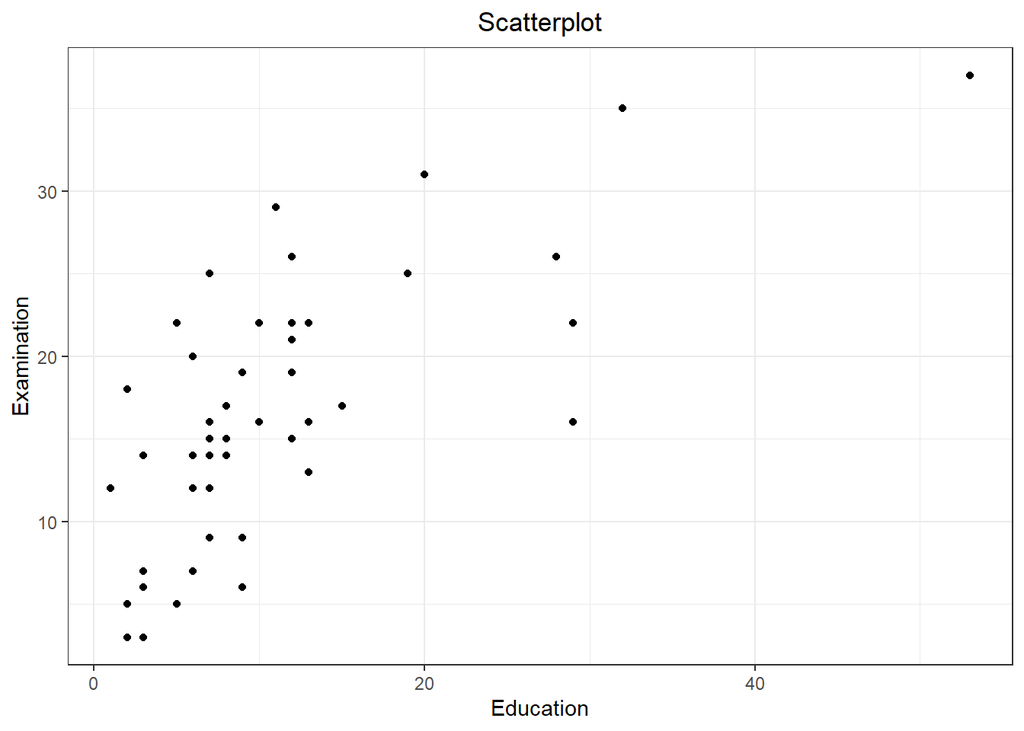

```r
library(ggplot2)

ggplot(swiss, aes(x = Education, y = Examination)) +
  geom_point() +
  labs(x = "Education", y = "Examination", title = "Scatterplot") +
  theme_bw() +
  theme(plot.title = element_text(hjust = 0.5))
```

```r
#looks there there could be a positive relationship between Examination and Education
# as Examination score increases, Education also increases
```

10. It is also useful to be able to write your own functions in `R`. Sometimes, `R` doesn’t have a function for exactly what you are looking for. Doing so is pretty straightforward. For a quick review, see: https://swcarpentry.github.io/r-novice-inflammation/02-func-R/
- For example, if I wanted to write a function that evaluated the equation
  $$f(x, y) = xy$$
  I could write one of the following options:

```r
#example 1
fun_ex1 <- function(params) {
  x <- params[1]
  y <- params[2]

  result <- x*y

  return(result)
}

#evaluate
fun_ex1(c(3,4))
```

```
## [1] 12
```

```r
#example 2
fun_ex2 <- function(x, y) {

  result <- x*y

  return(result)
}

#evaluate
fun_ex2(3,4)
```

```
## [1] 12
```

- Now your turn. Write a function that evaluates the following equation:
  $$f(x, y, z) = x^2 + 3xy + \sin(z)$$
- Have this function takes a vector as its single argument (see example 1), made up of the three parameters ($x, y, z$). Evaluate the function at $x = 3/4, y = 13, z = 3.4$.

```r
#function for the above equation
my_fun <- function(params){
  x <- params[1]
  y <- params[2]
  z <- params[3]

  result <- x^2 + 3*x*y + sin(z)

  return(result)
}

#evaluating the function at x = 3/4, y = 13, z = 3.4
my_fun(c(3/4, 13, 3.4))
```

```
## [1] 29.55696
```

# Math Review:

11. **Exercise**: Let’s try out some linear algebra. Below are 2 vectors, a and b, and two matrices A and B. Use them for this section.
- Here is a link to a linear algebra cheat sheet in R (and other languages): https://github.com/scalanlp/breeze/wiki/Linear-Algebra-Cheat-Sheet

```r
#a
a <- c(4, -5, 4, 1)
#b
b <- c(3, 2, -7, 17)

#A
A <- matrix(c(1, -3, 4, 5, 6, 8, 9, -10), ncol = 4)

#B
B <- matrix(c(4:1, 8, 14, -2, 1), ncol = 2)
```

1. What is the dot product of $\mathbf{a}$ and $\mathbf{b}$?
2. Does the result change if we take the dot product of $\mathbf{b}$ and $\mathbf{a}$?
3. What are the dimensions for the matrix $\mathbf{A}\mathbf{B}$? Is this new matrix invertible?
4. What are the eigenvectors (vector whose direction remains unchanged when a linear transformation is applied to it) and eigenvalues (scalars associated with a linear system of equations) of this new matrix?
5. Verify that the values produced are actually eigenvalues.

```r
#dot product
a %*% b
```

```
##      [,1]
## [1,]   -9
```

```r
b %*% a
```

```
##      [,1]
## [1,]   -9
```

```r
#AB
AB <- A %*% B
solve(AB)
```

```
##             [,1]       [,2]
## [1,]  0.10471204 -0.3193717
## [2,] -0.04712042  0.1937173
```

```r
dim(AB)
```

```
## [1] 2 2
```

```r
#yes it is invertible

#eigen vectors and values
eigen_AB <- eigen(AB)

#verifying that they are eigenvalues by checking that det(AB−λiI)=0 for each value
sapply(eigen_AB$values, function(x) det(AB - diag(2)*x))
```

```
## [1] 1.167058e-13 0.000000e+00
```